# Coursera: Intro to Computational Finance: Assignment 1b: Computing Asset Retrns with R

Go to http://finance.yahoo.com and download monthly data on Starbucks (ticker symbol sbux) over the 15 year period March 31, 1993 to March 31, 2008. Read the data into Excel and make sure to re-order the data so that time runs forward. Do your analysis on the monthly closing price data (which should be adjusted for dividends and stock splits). Name the spreadsheet tab with the data “data”.

```
curl 'http://real-chart.finance.yahoo.com/table.csv?s=SBUX&a=2&b=31&c=1993&d=2&e=31&f=2008&g=m&ignore=.csv' \
     -o sbux.monthly.csv
```

1. Make a time plot (line plot in Excel) of the monthly price data over the period (end of) March 1993 through (end of) March 2008.

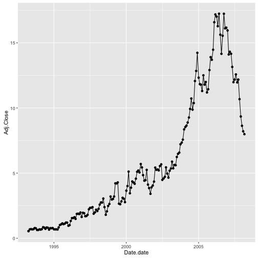

```r
    df = read.csv("sbux.monthly.csv")

    # Convert to date format.
    # Otherwise Date will be interpreted as a factor variable.
    # This matters when using Date on the x-axis in plots.
    # Apparently ggplot2 won't (easily) render line plots when
    # plotting a number var against a factor var.
    df$Date.date = as.Date(df$Date, "%Y-%m-%d")

    df = df[order(df$Date.date),]

    library(ggplot2)
    qplot(Date.date, Adj.Close, data=df, geom=c("point", "line"))
```

2. If you invested $1,000 at the end of March 1993, approximately (round to the nearest thousand) what would your investment be worth at the end of March 2008?

```r
    # simple return = delta-P / P0
    pt0 = df[1,]$Adj.Close
    pt1 = df[nrow(df),]$Adj.Close
    R = (pt1 - pt0) / pt0
    PV = 1000
    FV = PV * (1 + R)
    FV
```

```
## [1] 14736.84
```

Answer: `FV = 14736.84`

3. What is the approximate annual rate of return over this period assuming annual compounding? (Hint: what is the eﬀective annual rate for the 15 year investment?)

```r
    # convert simple return to annually compounding annual rate
    # (1 + R_a)^15 = (1 + R)
    R_a = (1 + R)^(1/15) - 1
    R_a
```

```
## [1] 0.1964475
```

Answer: `R_a = 0.1964475`

4. Make a time plot of the natural logarithm of monthly price data over the period March 1993 to March 2008

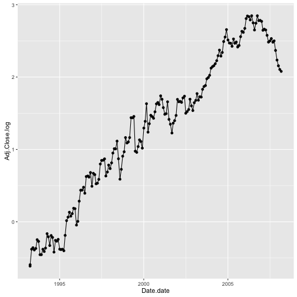

```r
    df$Adj.Close.log = log(df$Adj.Close)
    qplot(Date.date, Adj.Close.log, data=df, geom=c("point", "line"))
```

5. Using the monthly price data over the period March 1993 to March 2008 in the “data” tab, compute simple monthly returns (Starbucks does not pay a dividend). When computing returns, use the convention that Pt is the end of month closing price. Make a time plot of the monthly returns. Keep in mind that the returns are percent per month.

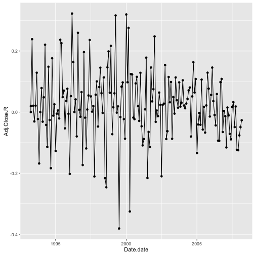

```r
    # R_m = numeric(nrow(df))

    # for (i in 2:nrow(df)) {
    #     pt0 = df[i-1,]$Adj.Close
    #     pt1 = df[i,]$Adj.Close
    #     R_m[i] = (pt1 - pt0) / pt0
    # }

    # ....OR....
    n = nrow(df)
    R_m = numeric(n)
    R_m[2:n] = ( df$Adj.Close[2:n] - df$Adj.Close[1:(n-1)] ) / df$Adj.Close[1:(n-1)]

    df$Adj.Close.R = R_m

    qplot(Date.date, Adj.Close.R, data=df, geom=c("point", "line"))
```

6. Compute simple annual returns for the years 1993 through 2008 (note: there are easy and hard ways to do this). Make a time plot of the annual returns.

Note: You may compute annual returns using overlapping data or non-overlapping data. With overlapping data you get a series of annual returns for every month. That is, the ﬁrst month annual return is from the end of March, 1993 to the end of March, 1994. The second month annual return is from the end of April, 1993 to the end of April, 1994 etc. With non-overlapping data you get a series of 15 annual returns for the 15 year period 1993:March - 2008:March. That is, the annual return for 1993:March - 1994:March is computed from the end of March 1993 through the end of March 1994. The second annual return is computed from the end of March 1994 through the end of March 1995 etc.

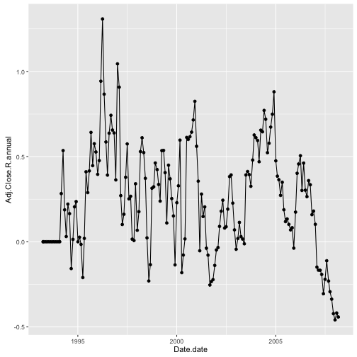

```r
    R_a = numeric(nrow(df))

    # for (i in 13:nrow(df)) {
    #     pt0 = df[i-12,]$Adj.Close
    #     pt1 = df[i,]$Adj.Close
    #     R_a[i] = (pt1 - pt0) / pt0
    # }

    # ....OR....
    n = nrow(df)
    R_a = numeric(n)
    p = 12        # period
    R_a[(p+1):n] = ( df$Adj.Close[(p+1):n] - df$Adj.Close[1:(n-p)] ) / df$Adj.Close[1:(n-p)]

    df$Adj.Close.R.annual = R_a

    qplot(Date.date, Adj.Close.R.annual, data=df, geom=c("point", "line"))
```

7. Using the monthly price/return data over the period March 1993 to March 2008, compute continuously compounded (cc) monthly returns. Make a time plot of the monthly cc returns.

```r
    # Three ways to compute cc returns:
    # R_cc = log(1 + R)
    # R_cc = log( pt1 / pt0 )
    # R_cc = log(pt1) - log(pt0)

    # R_cc1 = numeric(nrow(df))
    # R_cc2 = numeric(nrow(df))
    # R_cc3 = numeric(nrow(df))

    # for (i in 2:nrow(df)) {

    #     R_cc1[i] = log(1 + df[i,]$Adj.Close.R)

    #     pt0 = df[i-1,]$Adj.Close
    #     pt1 = df[i,]$Adj.Close
    #     R_cc2[i] = log( pt1 / pt0 )

    #     pt0.log = df[i-1,]$Adj.Close.log
    #     pt1.log = df[i,]$Adj.Close.log
    #     R_cc3[i] = pt1.log - pt0.log
    # }


    # ...OR.....
    n = nrow(df)
    p = 1         # period

    R_cc1 = numeric(n)
    R_cc1[(p+1):n] = log(1 + df$Adj.Close.R[(p+1):n])

    R_cc2 = numeric(n)
    R_cc2[(p+1):n] = log(df$Adj.Close[(p+1):n]) - log(df$Adj.Close[1:(n-p)])

    R_cc3 = numeric(n)
    R_cc3[(p+1):n] = log(df$Adj.Close[(p+1):n] / df$Adj.Close[1:(n-p)])

    # verify they're (pretty much) the same
    sum(R_cc1 - R_cc2)
```

```
## [1] -6.394624e-16
```

```r
    sum(R_cc2 - R_cc3)
```

```
## [1] 2.959872e-16
```

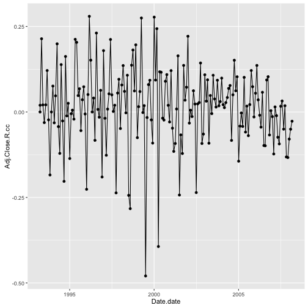

```r
    df$Adj.Close.R.cc = R_cc1

    qplot(Date.date, Adj.Close.R.cc, data=df, geom=c("point", "line"))
```

8. Compute continuously compounded annual returns for the years 1993 through 2008 (Again, there are easy and hard ways to do this). Make a time plot of the annual returns.

```r
    # Three ways to compute cc returns:
    # R_cc = log(1 + R)
    # R_cc = log( pt1 / pt0 )
    # R_cc = log(pt1) - log(pt0)

    # R_cca = numeric(nrow(df))

    # for (i in 13:nrow(df)) {
    #     R_cca[i] = log(1 + df[i,]$Adj.Close.R.annual)
    # }

    # ...OR.....
    n = nrow(df)
    p = 12         # period

    R_cca1 = numeric(n)
    R_cca1[(p+1):n] = log(1 + df$Adj.Close.R.annual[(p+1):n])

    R_cca2 = numeric(n)
    R_cca2[(p+1):n] = log(df$Adj.Close[(p+1):n]) - log(df$Adj.Close[1:(n-p)])

    R_cca3 = numeric(n)
    R_cca3[(p+1):n] = log(df$Adj.Close[(p+1):n] / df$Adj.Close[1:(n-p)])

    # verify they're (pretty much) the same
    sum(R_cca1 - R_cca2)
```

```
## [1] -7.979728e-17
```

```r
    sum(R_cca2 - R_cca3)
```

```
## [1] -1.654926e-15
```

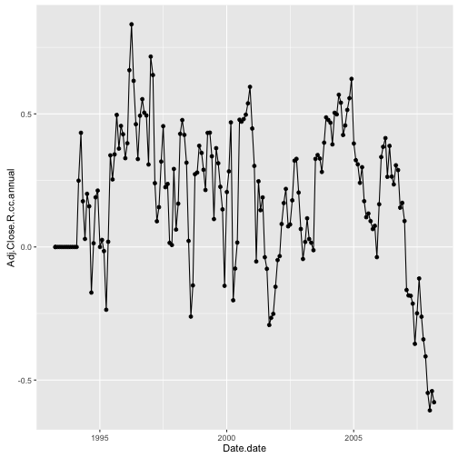

```r
    R_cca = R_cca1

    df$Adj.Close.R.cc.annual = R_cca

    qplot(Date.date, Adj.Close.R.cc.annual, data=df, geom=c("point", "line"))
```

9. Calculate the growth of $1 invested in SBUX.

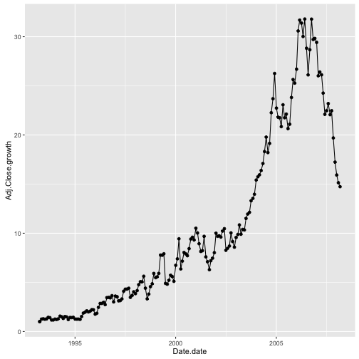

```r
    # gross returns = 1 + simple returns
    df$Adj.Close.R.gross = 1 + df$Adj.Close.R

    # growth of $1 equals the cumulative product of the gross returns
    df$Adj.Close.growth = cumprod(df$Adj.Close.R.gross)

    qplot(Date.date, Adj.Close.growth, data=df, geom=c("point", "line"))
```